# 13. Calibrationless CS-pMR image reconstruction from undersampled Cartesian data

$\leadsto$ The calibrationless reconstruction using the Ordered Weighted L1-norm (OWL) regularization leads to a better reconstructed image quality compared to using the Group-LASSO regularization :

OWL applies the non-uniform shrinkage to the wavelet coefficients however Group-LASSO regularization enforces block sparsity. Thus the OWL is more accurate than the Group-LASSO regularization, it effectively handles the high frenquency components and suppressing of noise.

**Q2**

Compare calibrationless reconstruction to the self-calibrated version you run previously in the Cartesian setting (in 3.), both in terms of image quality and computing time.

$\leadsto$ Self-calibrated reconstruction results in both improved reconstructed image quality and reduced computing time compared to the calibrationless reconstruction.

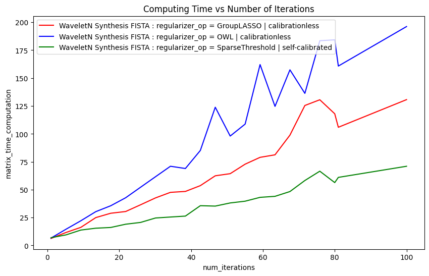

```python
# Add a main title (suptitle) to the figure
fig.suptitle("Computing Time")

# Display the figure with adjusted layout
plt.tight_layout(rect=[0, 0, 1, 0.96])  # Adjust layout to fit suptitle
plt.show()

plt.figure(figsize=(10, 6))

# WaveletN Synthesis FISTA plot  "GroupLASSO"
plt.plot(vector_num_iterations, matrix_time_computation[:, 0], linestyle='-', color='red',
        markersize=8, markerfacecolor='red', label='WaveletN Synthesis FISTA : regularizer_op = GroupLASSO | calibrationless')

# WaveletN Synthesis FISTA plot "OWL"
plt.plot(vector_num_iterations, matrix_time_computation[:, 1], linestyle='-', color='blue',
        markersize=8, markerfacecolor='blue', label='WaveletN Synthesis FISTA : regularizer_op = OWL | calibrationless')

# WaveletN Synthesis FISTA plot "OWL"
plt.plot(vector_num_iterations, matrix_time_computation[:, 2], linestyle='-', color='green',
        markersize=8, markerfacecolor='green', label='WaveletN Synthesis FISTA : regularizer_op = SparseThreshold | self-calibrated')

# Labels and title
plt.xlabel('num_iterations')
plt.ylabel('matrix_time_computation')
plt.title('Computing Time vs Number of Iterations')

# Grid and legend
# plt.grid(True)
plt.legend()

# Show the plot
plt.show()
```

[output not shown]